# Brain deviations in schizophrenia cohort

Anna Huang

2023-11-16

# Summary

In this project we are examining the centile results from GAMLSS models.

# Data

Loading in data about centiles so that we can do group comparions in the schizophrenia cohort.

```r
data = read.csv("KaidiReports/data_centiles_Oct20.csv")
behavdata = read.csv("Data_Management/PSYXSEC/PSYXSECPhenoDataSCIPPANSS.csv")
hcpbehav = read.csv("Data_Management/HCP_cognitive.csv")
#data = read.csv("D:/OneDrive - VUMC/Work/Lifespan/KaidiReports/data_centiles_Sept27.csv")
```

```r
# Subset data into the HCP dataset and PSYXSEC datasets
data$dx_group = data$Diagnosis
data$dx_group[data$Diagnosis != "Normal Control"] = "Schizophrenia Spectrum"
data$dx_group <- as.factor(data$dx_group)
hcp <- subset(data,Dataset == "HCP")
psyxsec <- subset(data,Dataset == "PSYXSEC")
Nucleus <- c("AV","AV","VA","VA","VL","VL","VPL","VPL",
                  "Pul","Pul","LGN","LGN","MGN","MGN","CM","CM","MD","MD")
Hemisphere <- c("Right","Left","Right","Left","Right","Left","Right","Left",
                  "Right","Left","Right","Left","Right","Left","Right","Left","Right","Left")
```

# Comparing centile medians between groups

Present the centile values in a table that includes the median centile values for SZ and HC, then compare group medians using the Wilcoxon Rank Sum test

```r
#### Right AV
## plot SZ vs HC Centiles cores as density maps
w.test <- data.frame(matrix(data=NA,nrow=18,ncol=9))
colnames(w.test) <- c("Nucleus","Hemisphere","SZmed","HCmed","W","L.conf","H.conf","shift","pval")
w.test$Nucleus <- Nucleus
w.test$Hemisphere <- Hemisphere

for (i in 1:18) {
  variablename <- paste('centile_',substr(w.test$Hemisphere[i],1,1),'.',w.test$Nucleus[i],sep="")
  SZ.med <- median(psyxsec[psyxsec$dx_group=="Schizophrenia Spectrum",variablename])
  HC.med <- median(psyxsec[psyxsec$dx_group=="Normal Control",variablename])
  test.results <- wilcox.test(psyxsec[,variablename]~psyxsec[,"dx_group"],conf.int=TRUE)
  w.test[i,3] <- SZ.med
  w.test[i,4] <- HC.med
  w.test[i,"W"] <- test.results$statistic
  w.test[i,"pval"] <- test.results$p.value
  w.test[i,"L.conf"] <- test.results$conf.int[1]
  w.test[i,"H.conf"] <- test.results$conf.int[2]
  w.test[i,"shift"] <- test.results$estimate
}

w.test$fdr <- p.adjust(w.test[,"pval"], method="fdr")
print(w.test)
```

```
##    Nucleus Hemisphere     SZmed     HCmed     W       L.conf     H.conf
## 1       AV      Right 0.4559095 0.4786251 25649 -0.035156056 0.07741968
## 2       AV       Left 0.3111702 0.4497369 28586  0.024373662 0.13273092
## 3       VA      Right 0.3877484 0.5224547 26972 -0.008022513 0.11098383
## 4       VA       Left 0.4683708 0.5028867 25061 -0.052028146 0.05857704
## 5       VL      Right 0.3987596 0.5161905 27115 -0.004145016 0.11257288
## 6       VL       Left 0.4250763 0.4951669 27785  0.008797679 0.12659750
## 7      VPL      Right 0.4152511 0.4801843 26728 -0.012229524 0.09952360
## 8      VPL       Left 0.4650042 0.4439568 24830 -0.050397657 0.06123158
## 9      Pul      Right 0.2870898 0.4773566 30074  0.055112409 0.16935213
## 10     Pul       Left 0.3210684 0.4780267 29580  0.045442421 0.16209070
## 11     LGN      Right 0.2946237 0.4650020 29440  0.040087335 0.15941389
## 12     LGN       Left 0.3657491 0.4580793 27195 -0.002634341 0.11047333
## 13     MGN      Right 0.3880616 0.5281175 29114  0.035923041 0.15541439
## 14     MGN       Left 0.3470209 0.5042187 28930  0.033295915 0.15483286
```

[output cut: 23 more lines]

# Calculating deviance status

Identifying infra-normal and supra-normal individuals in the schizophrenia cohort.

Infra-normal = lower than 5% of population Supra-normal = greater than 95% of population

```r
for (i in 1:18) {
    infra <- as.numeric(psyxsec[,paste('centile_',substr(Hemisphere[i],1,1),'.',Nucleus[i], sep='')] < 0.05)
    supra <- as.numeric(psyxsec[,paste('centile_',substr(Hemisphere[i],1,1),'.',Nucleus[i], sep='')] > 0.95)
    centcat <- (infra*-1) + supra
    psyxsec <- cbind(psyxsec,centcat)
    colnames(psyxsec)[ncol(psyxsec)] <-
      c(paste(Nucleus[i],'_',substr(Hemisphere[i],1,1),'.',"deviance",sep=""))
  }

#write.csv(psyxsec,"psyxsec.csv")
```

# Identify HC individuals falling within 90% of population

Checking validity of normative models when applied to schizophrenia dataset. Here we identify the proportion of healthy individuals that fall within the middle 90% of the population. For a valid model, proportion should fall around .9.

```r
prop.hc <- data.frame(matrix(data=NA,nrow=18,ncol=4))
colnames(prop.hc) <- c("Nucleus","Hemisphere","Schizophrenia","Healthy Controls")
prop.hc$Nucleus <- Nucleus
prop.hc$Hemisphere <- Hemisphere
group.names <- c("Schizophrenia Spectrum","Normal Control")


for (i in 1:18) {
#  variablename <- paste('centile_',substr(w.test$Hemisphere[i],1,1),'.',w.test$Nucleus[i],sep="")
  variablename <- paste(Nucleus[i],'_',substr(Hemisphere[i],1,1),'.',"deviance",sep="")
  prop.hc[i,3] <- (sum(psyxsec[psyxsec$dx_group=="Schizophrenia Spectrum",variablename]==0)/234) * 100
  prop.hc[i,4] <- (sum(psyxsec[psyxsec$dx_group=="Normal Control",variablename]==0)/211) * 100
}

print(prop.hc)
```

```
##    Nucleus Hemisphere Schizophrenia Healthy Controls
## 1       AV      Right      84.61538         88.62559
## 2       AV       Left      81.62393         85.78199
## 3       VA      Right      82.05128         85.30806
## 4       VA       Left      79.91453         77.25118
## 5       VL      Right      77.35043         82.46445
## 6       VL       Left      78.20513         84.83412
## 7      VPL      Right      77.77778         84.83412
## 8      VPL       Left      81.19658         85.78199
## 9      Pul      Right      78.63248         86.72986
## 10     Pul       Left      78.63248         89.09953
## 11     LGN      Right      79.91453         84.36019
## 12     LGN       Left      82.90598         87.20379
## 13     MGN      Right      82.05128         83.88626
## 14     MGN       Left      78.20513         88.62559
## 15      CM      Right      83.76068         85.30806
## 16      CM       Left      81.62393         85.78199
## 17      MD      Right      79.48718         78.67299
## 18      MD       Left      78.63248         85.30806
```

# Identifying proportion of infra- and supra-normal individuals in schizophrenia cohort

Identify the proportions of individuals that fall outside 90% of the population, and then plot the proportions of infra-normal and supra-normal individuals in the healthy control and schizophrenia groups (Figure 3).

```r
prop.90 <- data.frame(matrix(data=NA,nrow=18,ncol=6))
colnames(prop.90) <- c("Nucleus","Hemisphere","SZinfra","SZsupra","HCinfra","HCsupra")
prop.90$Nucleus <- Nucleus
prop.90$Hemisphere <- Hemisphere
group.names <- c("Schizophrenia Spectrum","Normal Control")

for (i in 1:18) {
  variablename <- paste(Nucleus[i],'_',substr(Hemisphere[i],1,1),'.',"deviance",sep="")
  prop.90[i,3] <- (sum(psyxsec[psyxsec$dx_group=="Schizophrenia Spectrum",variablename]==-1)/234) * 100
  prop.90[i,4] <- (sum(psyxsec[psyxsec$dx_group=="Schizophrenia Spectrum",variablename]==1)/234) * 100
  prop.90[i,5] <- (sum(psyxsec[psyxsec$dx_group=="Normal Control",variablename]==-1)/211) * 100
  prop.90[i,6] <- (sum(psyxsec[psyxsec$dx_group=="Normal Control",variablename]==1)/211) * 100
}

print(prop.90)
```

```
##    Nucleus Hemisphere   SZinfra  SZsupra   HCinfra   HCsupra
## 1       AV      Right  9.401709 5.982906  5.687204  5.687204
## 2       AV       Left 12.393162 5.982906  5.213270  9.004739
## 3       VA      Right 10.683761 7.264957  9.478673  5.213270
## 4       VA       Left 13.247863 6.837607 11.848341 10.900474
## 5       VL      Right 14.957265 7.692308  9.478673  8.056872
## 6       VL       Left 16.239316 5.555556  8.530806  6.635071
## 7      VPL      Right 15.384615 6.837607  7.582938  7.582938
## 8      VPL       Left  9.829060 8.974359  6.635071  7.582938
## 9      Pul      Right 17.521368 3.846154  5.687204  7.582938
## 10     Pul       Left 14.957265 6.410256  4.739336  6.161137
## 11     LGN      Right 15.384615 4.700855  9.478673  6.161137
## 12     LGN       Left 11.965812 5.128205  6.635071  6.161137
## 13     MGN      Right 13.675214 4.273504  7.582938  8.530806
## 14     MGN       Left 14.529915 7.264957  5.213270  6.161137
## 15      CM      Right 10.256410 5.982906  5.687204  9.004739
## 16      CM       Left 11.965812 6.410256  7.582938  6.635071
## 17      MD      Right 14.102564 6.410256  4.739336 16.587678
## 18      MD       Left 17.948718 3.418803  5.687204  9.004739
```

```r
infra.long <- melt(prop.90, id = c("Nucleus","Hemisphere"),
                  measure = c("SZinfra","HCinfra"),
                  variable.name = "Group",
                  value.name = "Infra")

infra.long$Group <- gsub("SZinfra","SZ",infra.long$Group)
infra.long$Group <- gsub("HCinfra","HC",infra.long$Group)

supra.long <- melt(prop.90, id = c("Nucleus","Hemisphere"),
                  measure = c("SZsupra","HCsupra"),
                  variable.name = "Group",
                  value.name = "Supra")

supra.long$Group <- gsub("SZsupra","SZ",supra.long$Group)
supra.long$Group <- gsub("HCsupra","HC",supra.long$Group)

all.long <- merge(x = infra.long, y = supra.long, by.x = c("Nucleus","Hemisphere","Group"), by.y = c("Nucleus","Hemisphere","Group"))

rm(infra.long,supra.long)
```

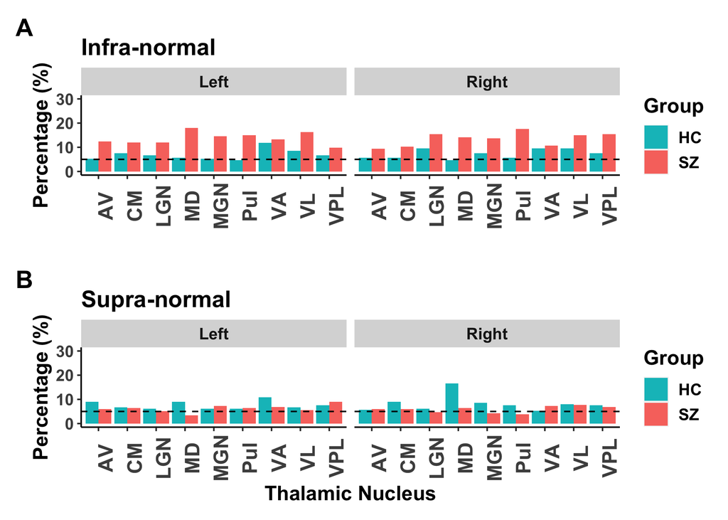

```r
p5.inf <- ggplot(data=all.long, aes(x=Nucleus,y=Infra,fill=Group)) + facet_wrap(~ Hemisphere)
p5.sup <- ggplot(data=all.long, aes(x=Nucleus,y=Supra,fill=Group)) + facet_wrap(~ Hemisphere)



p5.infplot <- p5.inf + geom_bar(stat="identity",position=position_dodge()) + ggtitle('Infra-normal') +
  geom_hline(yintercept=5, linetype="dashed", color = "black") +
 theme(axis.text.x = element_text(angle = 90, size=14,face="bold"),
        text = element_text(size = 14,face="bold"),
        axis.line = element_line(colour="black"),
        panel.background = element_blank(),
        plot.title = element_text(size = 16, face = "bold")) +
  labs(y="Percentage (%)",x="") +
  scale_fill_manual(breaks=c("HC","SZ"),values=c("#00BFC4","#F8766D")) +
  ylim(0,30)

p5.supplot <- p5.sup + geom_bar(stat="identity",position=position_dodge()) + ggtitle('Supra-normal') +
    geom_hline(yintercept=5, linetype="dashed", color = "black") +
  theme(axis.text.x = element_text(angle = 90, size=14,face="bold"),
        text = element_text(size = 14,face="bold"),
        axis.line = element_line(colour="black"),
        panel.background = element_blank(),
        plot.title = element_text(size = 16, face = "bold")) +
    labs(y="Percentage (%)",x="Thalamic Nucleus") +
  scale_fill_manual(breaks=c("HC","SZ"),values=c("#00BFC4","#F8766D")) +
  ylim(0,30)

patchwork <- p5.infplot + p5.supplot + plot_layout(nrow=2)
fig3ab <- patchwork + plot_annotation(tag_levels = 'A')
fig3ab
```

```r
ggsave(file="Figure3.eps",fig3ab)
```

# Comparing deviances between groups

Calculating differences in the proportion of infra-, normal and supra-normal indivivudals in the schizophrenia and healthy control groups for each thalamic nucleus.

```r
centileX <- data.frame(matrix(data=NA,nrow=18,ncol=7))
colnames(centileX) <- c("Nucleus","SZinfra","SZnorm","SZsupra","HCinfra","HCnorm","HCsupra")
centileX$Nucleus <- Nucleus
centileX$Hemisphere <- Hemisphere
group.names <- c("Schizophrenia Spectrum","Normal Control")


for (i in 1:18) {
  variablename <- paste(Nucleus[i],'_',substr(Hemisphere[i],1,1),'.',"deviance",sep="")
  centileX[i,2] <- sum(psyxsec[psyxsec$dx_group=="Schizophrenia Spectrum",variablename]==-1)
  centileX[i,3] <- sum(psyxsec[psyxsec$dx_group=="Schizophrenia Spectrum",variablename]==0)
  centileX[i,4] <- sum(psyxsec[psyxsec$dx_group=="Schizophrenia Spectrum",variablename]==1)
  centileX[i,5] <- sum(psyxsec[psyxsec$dx_group=="Normal Control",variablename]==-1)
  centileX[i,6] <- sum(psyxsec[psyxsec$dx_group=="Normal Control",variablename]==0)
  centileX[i,7] <- sum(psyxsec[psyxsec$dx_group=="Normal Control",variablename]==1)
  rm(variablename)
}

for (i in 1:18) {
  SZdata <- centileX[i,2:4]
  colnames(SZdata) <- c("infra","norm","supra")
  HCdata <- centileX[i,5:7]
  colnames(HCdata) <- c("infra","norm","supra")
  testdata <- rbind(SZdata,HCdata)
  rownames(testdata) <- c("SZ","HC")
  chisq <- chisq.test(testdata)
  #cramv <- cramersv(chisq)
  centileX[i,"Chisq"] = chisq$statistic
  centileX[i,"pval"]=chisq$p.value
  centileX[i,"cramv"]=cramersv(chisq)
}

centileX$fdr <- p.adjust(centileX[,"pval"], method="fdr")
print(centileX)
```

```
##    Nucleus SZinfra SZnorm SZsupra HCinfra HCnorm HCsupra Hemisphere     Chisq
## 1       AV      22    198      14      12    187      12      Right  2.226492
## 2       AV      29    191      14      11    181      19       Left  7.958890
## 3       VA      25    192      17      20    180      11      Right  1.042387
## 4       VA      31    187      16      25    163      23       Left  2.362529
## 5       VL      35    181      18      20    174      17      Right  3.076964
## 6       VL      38    183      13      18    179      14       Left  6.051495
## 7      VPL      36    182      16      16    179      16      Right  6.545961
## 8      VPL      23    190      21      14    181      16       Left  1.899504
## 9      Pul      41    184       9      12    183      16      Right 16.686461
## 10     Pul      35    184      15      10    188      13       Left 12.920508
## 11     LGN      36    187      11      20    178      13      Right  3.781350
## 12     LGN      28    194      12      14    184      13       Left  3.792584
## 13     MGN      32    192      10      16    177      18      Right  7.058897
## 14     MGN      34    183      17      11    187      13       Left 11.173216
```

[output cut: 23 more lines]

# Associations with Cognition

Calculating the association between SCIP composite score (cognition) and deviance scores (centiles) amd raw volumes (standardized for age, sex, race and eTIV)

```r
# Create function for calcuating correlations for centiles and standardized raw scores
table_rho <- function(y,Nucleus,Hemisphere, dataset = data) {
  #Setup function to calculate correlations
  corr <- data.frame(matrix(data=NA,nrow=18,ncol=6))
  colnames(corr) <- c("Nucleus","Hemisphere","centile_rho","centile_p","raw_rho","raw_p")
  corr$Nucleus <- Nucleus
  corr$Hemisphere <- Hemisphere

  #  corr$Nucleus <- c("AV","AV","VA","VA","VL","VL","VPL","VPL",
#                  "Pul","Pul","LGN","LGN","MGN","MGN","CM","CM","MD","MD")
#  corr$Hemisphere <- c("Right","Left","Right","Left","Right","Left","Right","Left",
#                  "Right","Left","Right","Left","Right","Left","Right","Left","Right","Left")

  for (i in 1:18) {
    centnuc <- paste("centile_",substr(corr$Hemisphere[i],1,1),'.',corr$Nucleus[i],sep="")
    resnuc <- paste("res_",substr(corr$Hemisphere[i],1,1),".",corr$Nucleus[i],sep="")
    centile = cor.test(dataset[,centnuc],dataset[,y], use = "pairwise.complete.obs",method="spearman",exact=FALSE)
    raw = cor.test(dataset[,resnuc],dataset[,y], use = "pairwise.complete.obs", method="spearman",exact=FALSE)
    corr[i,3] <- centile$estimate
    corr[i,4] <- centile$p.value
    corr[i,5] <- raw$estimate
    corr[i,6] <- raw$p.value
  }

  corr$centile_fdr <- p.adjust(corr[,"centile_p"], method="fdr")
  corr$raw_fdr <- p.adjust(corr[,"raw_p"], method = "fdr")

  return(corr)
}
```

```r
draw_rho <- function(name,corr=corr_f) {
  rho.long <- melt(corr, id = c("Nucleus","Hemisphere"),
                  measure = c("centile_rho","raw_rho"),
                  variable.name = "Type",
                  value.name = "Rho")
  rho.long$Type <- gsub("centile_rho","Centiles",rho.long$Type)
  rho.long$Type <- gsub("raw_rho","Std Vols",rho.long$Type)

  pval.long <- melt(corr, id = c("Nucleus","Hemisphere"),
                  measure = c("centile_fdr","raw_fdr"),
                  variable.name = "Type",
                  value.name = "pvalue")
  label(pval.long[["pvalue"]]) <- "P-value"
  pval.long$Type <- gsub("centile_fdr","Centiles",pval.long$Type)
  pval.long$Type <- gsub("raw_fdr","Std Vols",pval.long$Type)

  corr.long <- merge(x = rho.long, y = pval.long,
                     by.x = c("Nucleus","Hemisphere","Type"), by.y = c("Nucleus","Hemisphere","Type"))

# Heatmap for Rho
 corr.plot <- ggplot(corr.long, aes(Nucleus, Type, fill= pvalue)) +
   geom_tile() +
   geom_text(aes(Nucleus,Type, label = round(Rho,3)), size=4) +
   facet_wrap(~Hemisphere, nrow=2) +
   ggtitle(paste(name)) +
   scale_fill_gradientn(colours=c("white","yellow","orange","red"),limits=c(0,1)) +
#                       , values=rescale(c(-1,0-.Machine$double.eps,0,0+.Machine$double.eps,1)),limits=c(0,1)) +
    theme(
      panel.grid.major = element_blank(),panel.grid.minor = element_blank(), panel.background = element_blank(),
   #   axis.text = element_text(face="bold"),
      axis.title.x = element_blank(),
      axis.title.y = element_blank(),
      text = element_text(size = 14,face="bold"),
      axis.text.x = element_text(angle = 90, size=14, face="bold"),
      axis.text.y = element_text(color = "black", size = 14, face = "bold"),
      plot.title = element_text(size = 16, face = "bold")
    #  axis.text.y = element_text(angle = 90, hjust = 1)
      ) +
  coord_fixed() + labs(fill="p-values")

  return(corr.plot)
}
```

```r
# Merge centile values with cognitive measures
psyxsecBEH <- merge(x = psyxsec, y = behavdata, by.x = "Subject", by.y = "XNAT.Subject.ID")

label(psyxsecBEH$Positive.Sub.Scale) <- "PANSS Positive"
label(psyxsecBEH$Negative.Sub.Scale) <- "PANSS Negative"
label(psyxsecBEH$General.Sub.Scale) <- "PANSS General"
label(psyxsecBEH$Total.Z.Score) <- "SCIP Total Score"

for (i in 1:18) {
  nucname <- paste("n",substr(Hemisphere[i],1,1),'.',Nucleus[i],sep="")
  resname <- paste("res_",substr(Hemisphere[i],1,1),'.',Nucleus[i],sep="")
  tp <- lm(eval(as.name(nucname)) ~ Age + Race + Sex + neTIV, data = psyxsecBEH)
  psyxsecBEH[,resname] <- rstandard(tp)
}

psyxsecBEH.SZ <- psyxsecBEH[psyxsecBEH$dx_group=="Schizophrenia Spectrum",]
psyxsecBEH.HC <- psyxsecBEH[psyxsecBEH$dx_group=="Normal Control",]

psyxsecBEH$Sex <- dplyr::recode(psyxsecBEH$Sex,
                                "F" = "Female",
                                "M" = "Male")
```

## Plotting correlation schores

```r
my.render.cont <- function(x) {
  with(stats.apply.rounding(stats.default(x), digits=4), c("",
                                                           "Mean (SD)"=sprintf("%s (&plusmn;%s)", MEAN, SD)))
}

my.render.cat <- function(x) {
  c("", sapply(stats.default(x), function(y) with(y, sprintf("%d (%0.0f %%)", FREQ, PCT))))
}

table1(~ Age + Sex + Race + Total.Z.Score | dx_group, data = psyxsecBEH, render.continuous = my.render.cont, render.categorical=my.render.cat)
```

|  | Normal Control (N=211) | Schizophrenia Spectrum (N=234) | Overall (N=445) |
| --- | --- | --- | --- |
| Age |  |  |  |
| Mean (SD) | 29.15 (±10.05) | 29.19 (±10.96) | 29.17 (±10.53) |
| Sex |  |  |  |
| Female | 80 (38 %) | 68 (29 %) | 148 (33 %) |
| Male | 131 (62 %) | 166 (71 %) | 297 (67 %) |
| Race |  |  |  |
| AA | 48 (23 %) | 76 (32 %) | 124 (28 %) |
| Other | 13 (6 %) | 10 (4 %) | 23 (5 %) |
| White | 150 (71 %) | 148 (63 %) | 298 (67 %) |
| SCIP Total Score |  |  |  |
| Mean (SD) | 0.1091 (±0.6282) | -1.088 (±0.9767) | -0.5152 (±1.021) |
| Missing | 1 (0.5%) | 5 (2.1%) | 6 (1.3%) |

Spearman Rho correlation with cognition using centiles and standardized (corrected for covariates) raw volumes.

```r
sz.corr = table_rho("Total.Z.Score",Nucleus,Hemisphere,dataset=psyxsecBEH.SZ)
sz.plot <- draw_rho("Schizophrenia Group",corr=sz.corr)

sz.corr
```

```
##    Nucleus Hemisphere  centile_rho    centile_p       raw_rho      raw_p
## 1       AV      Right -0.009794850 0.8828041571  0.0052611594 0.93688893
## 2       AV       Left -0.016442997 0.8045346241  0.0178769498 0.78787701
## 3       VA      Right -0.039423221 0.5528146460  0.0283862780 0.66916245
## 4       VA       Left -0.038285052 0.5643455641 -0.0006155506 0.99260850
## 5       VL      Right  0.028973849 0.6627306996  0.0664404984 0.31681146
## 6       VL       Left  0.005776783 0.9307184612  0.0401576849 0.54543516
## 7      VPL      Right -0.007869255 0.9057240889  0.0118733325 0.85817391
## 8      VPL       Left  0.043559202 0.5119048321  0.0449511856 0.49849816
## 9      Pul      Right  0.185290738 0.0049079598  0.1283592977 0.05240023
## 10     Pul       Left  0.198135361 0.0025966897  0.1514024762 0.02191575
## 11     LGN      Right -0.084453349 0.2029139427 -0.0647937006 0.32898163
## 12     LGN       Left -0.092803254 0.1616015566 -0.0613382231 0.35548284
## 13     MGN      Right  0.141271872 0.0326093046  0.1020824798 0.12347228
## 14     MGN       Left  0.107319657 0.1052676203  0.0611543573 0.35692947
```

[output cut: 23 more lines]

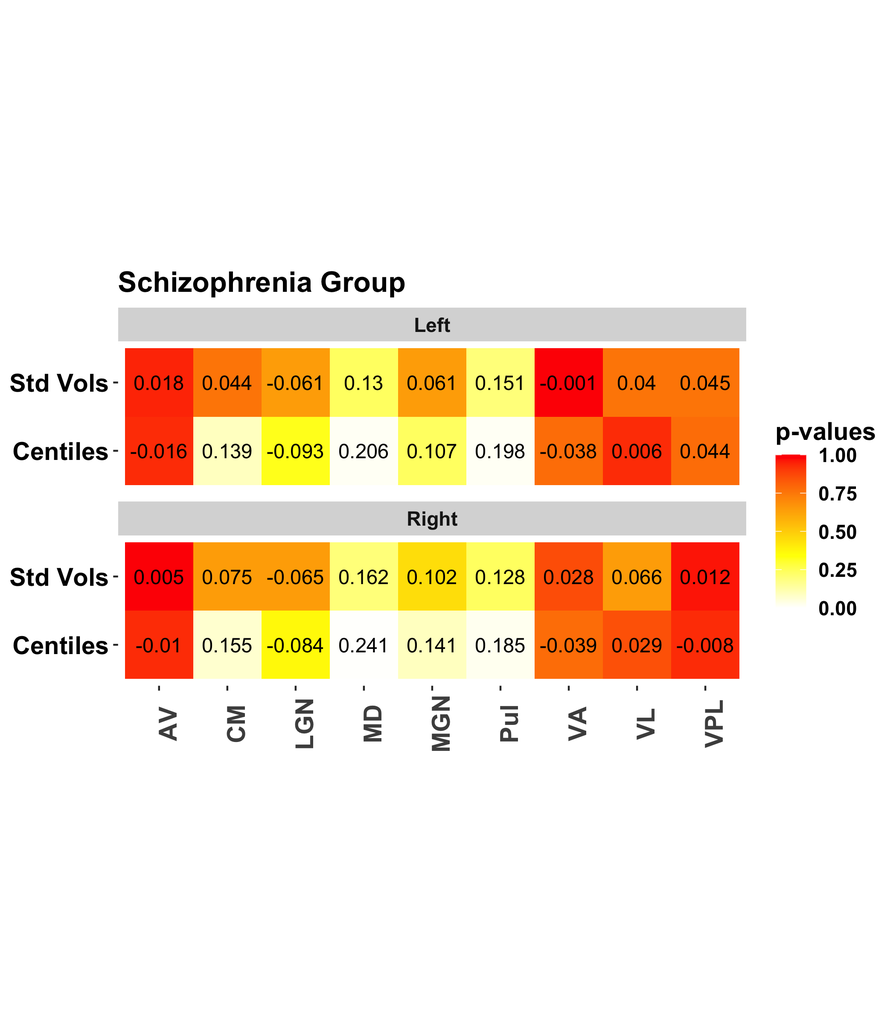

```r
sz.plot
```

```r
ggsave(file="Figure4.svg",sz.plot,width=7,height=4.5,units="in",dpi=600)
```

# Supplemental: Age distribution figures

Age distributions comparing HCP and schizophrenia datasets.

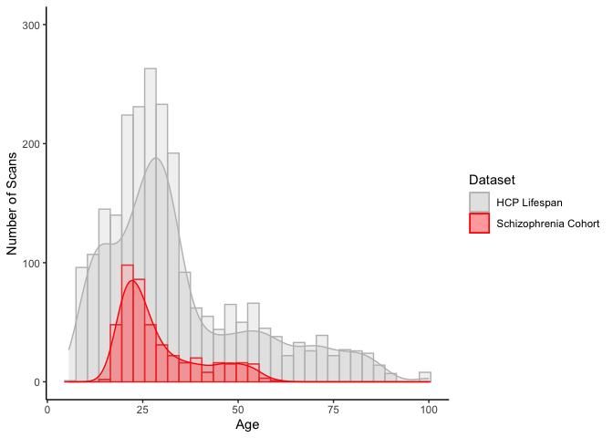

```r
data$Dataset <- factor(data$Dataset, levels=c("HCP","PSYXSEC"),
                       labels=c("HCP Lifespan","Schizophrenia Cohort"))

allagehist <- ggplot(data,aes(x=Age, color=Dataset,fill=Dataset)) +
  geom_histogram(alpha=.2,binwidth=3) +
  geom_density(aes(y=after_stat(count*3)),alpha=.25) +
  theme_classic() +
  ylab("Number of Scans") + ylim(c(0,300)) +
  scale_fill_manual(breaks=c("HCP Lifespan","Schizophrenia Cohort"),values=c("grey","#FF0000")) +
  scale_color_manual(breaks=c("HCP Lifespan","Schizophrenia Cohort"),values=c("grey","#FF0000"))


# show on page
allagehist
```

```r
# Print on page and save as eps file
ggsave("agedist_dataset.eps",allagehist,dpi=300)
```

Age distributions between diagnoses in psychosis cohort.

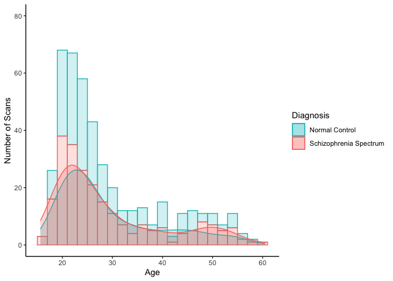

```r
psyagehist <- ggplot(psyxsec,aes(x=Age,color=dx_group,fill=dx_group)) +
  geom_histogram(alpha=.2,binwidth=2) +
  geom_density(aes(y=after_stat(count*2)),alpha=.25) +
  theme_classic() +
  ylab("Number of Scans") + ylim(c(0,80)) +
  guides(fill=guide_legend(title="Diagnosis"),color=guide_legend(title="Diagnosis")) +
  scale_fill_manual(breaks=c("Normal Control",
                             "Schizophrenia Spectrum"),values=c("#00BFC4","#F8766D")) +
  scale_color_manual(breaks=c("Normal Control",
                             "Schizophrenia Spectrum"),values=c("#00BFC4","#F8766D"))

# show on page
psyagehist
```

```r
# save as eps file
ggsave("agedist_diagnosis.eps",psyagehist,dpi=300)
```